# Statistical analysis of credit data

Exploratory Data Analysis (EDA) and Statistical Inference

Author

Horn, Jacobus (229150357)

Published

2025

```r
library(knitr)
options(width=80)
knitr::opts_chunk$set(echo = TRUE, message = FALSE, cache = TRUE)
opts_chunk$set(tidy.opts=list(width.cutoff=60),tidy=TRUE)

# packages'
library(sys)
library(reticulate)
library("png")
library("rjson")
library(imager)
library(ggplot2)
library(EnvStats)
library(kableExtra)
library(psych)
library(patchwork)
library(skimr)
library(gt)


library(tidyverse)
library(fitdistrplus)
library(MASS)
library(aqp)
library(nortest)

df<-read.csv("credit_data.csv")
```

## 1 Data

The data set we have been given consists of the following fields:  
1. occupation: Defines the occupation of the person.  
2. credit_rating: Is a categorical variable describing how good the persons credit rating is.  
3. number_of_late_payments: This is the amount of late payments that the person has made.  
4. debt_to_income_ratio: This is the ratio of your income and your debt. It shows how much of your income has to be payed as debt.  
5. credit_utilization_ratio: This is the ratio between your total credit limit and your total outstanding balance on all your credit cards.

```r
knitr::kable(head(df))
```

| id | occupation | credit_rating | number_of_late_payments | debt_to_income_ratio | credit_utilization_ratio |
| --- | --- | --- | --- | --- | --- |
| 1 | Engineer | Fair | 5 | 0.27 | 0.41 |
| 2 | Clerk | Fair | 4 | 0.43 | 0.39 |
| 3 | Manager | Fair | 1 | 0.40 | 0.35 |
| 4 | Nurse | Fair | 2 | 0.30 | 0.52 |
| 5 | Clerk | Poor | 4 | 0.66 | 0.51 |
| 6 | Salesperson | Good | 9 | 0.19 | 0.20 |

```python
import numpy as np
import matplotlib
import matplotlib.pyplot as plt
import scipy.stats as sc
import seaborn as sb
import statistics as stts
import pandas as pd
from fitter import Fitter, get_common_distributions, get_distributions
import csv
import statsmodels.api as sm
import json
import math
from distfit import distfit

id=[]
occupation=[]
credit_rating=[]
number_of_late_payments=[]
debt_to_income_ratio=[]
credit_utilization_ratio=[]
alldata=dict

allModels=['Fair','Good','Poor']
alloccupations= [
"Engineer",
"Clerk",
"Manager",
"Nurse",
"Salesperson",
"Teacher"]

allcolors="red","green","blue","yellow","orange","black"
with open('credit_data.csv', newline='') as csvfile:
    reader = csv.DictReader(csvfile)

    for row in reader:
        id.append(float(row['id']))
        occupation.append(row['occupation'])
        credit_rating.append(row['credit_rating'])
        number_of_late_payments.append(float(row['number_of_late_payments']))
        debt_to_income_ratio.append(float(row['debt_to_income_ratio']))
        credit_utilization_ratio.append(float(row['credit_utilization_ratio']))


    def generateMeanStandardDev(thisList):

        tmean=stts.mean(thisList)
        tstdev=stts.stdev(thisList)
        tvar=stts.variance(thisList)
        tharmmean=stts.harmonic_mean(thisList)
        tskew= sc.skew(thisList,axis=0,bias=True)
        tkurt=sc.kurtosis(thisList,axis=0,bias=True)
        tgeomean=0
        if 0 in thisList:
            tgeomean=0
        else:
            tgeomean=stts.geometric_mean(thisList)
        #print(tmean,tstdev,tvar)
        return [tmean,tstdev,tvar,tharmmean,tgeomean,tskew,tkurt,]

    def eachModelthing(row,query):
        icount=1
        allModels=['Fair','Good','Poor']
        for x in allModels:
                #print(x)

                thisoccupation={'id':[],'occupation':[],'credit_rating':[],'number_of_late_payments':[],'debt_to_income_ratio':[],'credit_utilization_ratio':[],'sum_of_each_rating':{}}
                for thisid in id:
                    thisid=int(thisid)-1
                    if  credit_rating[thisid]==x :

                        thisoccupation['id'].append(1)
                        thisoccupation['occupation'].append(occupation[thisid])
                        thisoccupation['credit_rating'].append(credit_rating[thisid])
                        thisoccupation['sum_of_each_rating']
                        thisoccupation['number_of_late_payments'].append(float(number_of_late_payments[thisid]))
                        thisoccupation['debt_to_income_ratio'].append(float(debt_to_income_ratio[thisid]))
                        thisoccupation['credit_utilization_ratio'].append(float(credit_utilization_ratio[thisid]))


                data = {
                "credit_utilization_ratio": thisoccupation['credit_utilization_ratio'],
                "number_of_late_payments": thisoccupation['number_of_late_payments'],
                "debt_to_income_ratio":thisoccupation['debt_to_income_ratio'],
                "occupation":thisoccupation['occupation'],
                "credit_rating":thisoccupation['credit_rating'],
                "id":thisoccupation['id']
                    }
                df = pd.DataFrame(data)
                df.head()

                sb.kdeplot(data=df, x=query, multiple="stack",color=allcolors[row],label=x,ax=axes[icount,row]).legend(loc="upper right")
                icount+=1
    def ShowDistribution(collum_name,place):
        data = {
        "credit_utilization_ratio": credit_utilization_ratio,
        "number_of_late_payments": number_of_late_payments,
        "debt_to_income_ratio":debt_to_income_ratio,
        "occupation":occupation,
        "credit_rating":credit_rating,
        "id":id
            }
        df = pd.DataFrame(data)
        df.head()
        thisfield = df[collum_name].values
        stuff=generateMeanStandardDev(data[collum_name])
        mean=stuff[0]
        stdev=stuff[1]
        vari=stuff[2]
        harmmean=stuff[3]
        geomean=stuff[4]
        linewidth=1
        gx=sb.kdeplot(data=df, x=collum_name, multiple="stack",ax=place,label=collum_name)
        gx.legend(loc="upper right")
        gx.set(xlabel=None)
        gx.set(ylabel=None)
        place.axvline(x = mean,  color="red"   , linewidth =linewidth)
        if harmmean !=0 :
            place.axvline(x = harmmean,  color="black"   , linewidth =linewidth)
        if geomean !=0 :
            place.axvline(x = geomean,  color="white"   , linewidth =linewidth)
        place.axvline(x = mean-vari  ,color="green" ,linewidth =linewidth)

        place.axvline(x =mean+vari, color="green",linewidth =linewidth     )

        place.axvline(x =mean-stdev, color="yellow" ,  linewidth =linewidth  )
        place.axvline(x =mean+stdev, color="yellow" ,linewidth =linewidth    )
        jdataDict={
            "name":collum_name,
            "mean":stuff[0],
            "standarddev":stuff[1],
            "variance":stuff[2],
            "harmmean":stuff[3],
            "geomean":stuff[4],
            "skewness":stuff[5],
            "kurtosis":stuff[6]
        }
        return jdataDict

    def boxplots(thing1_name):
        data = {
        "credit_utilization_ratio": credit_utilization_ratio,
        "number_of_late_payments": number_of_late_payments,
        "debt_to_income_ratio":debt_to_income_ratio,
        "occupation":occupation,
        "credit_rating":credit_rating,
        "id":id
            }
        df = pd.DataFrame(data)
        df.head()
        sb.boxplot(df,y=thing1_name,x="credit_rating",hue="occupation").legend( loc='best', borderaxespad=0, )
    def compare2things(thing1_name,thing2_name,df):


        regression=(sc.linregress(x=data[thing1_name],y=data[thing2_name]))
        #print(regression)
        b=regression[0]
        a=regression[1]
        point1=a+b*min(data[thing1_name])
        point2=a+b*max(data[thing1_name])

        pearsonC=sc.pearsonr(data[thing1_name],data[thing2_name])

        txtreturn="name1 "+thing1_name+"\nname2"+thing2_name+"\npearson_coefficient"+str(pearsonC[0])+"\npearson_p_value"+str(pearsonC[1])+          "\nregression_line"+f"y={a}+{b}*x"
        jdataDict={
            "name1":thing1_name,
            "name2":thing2_name,
            "pearson_coefficient":pearsonC[0],
            "pearson_p_value":pearsonC[1],
            "regression_line":f"y={a}+{b}*x"
        }
        return jdataDict
        #return txtreturn




    #print(len(credit_utilization_ratio))
    #print(len(number_of_late_payments))
    #print(len(debt_to_income_ratio))

    #print(len(occupation))

    #print(len(credit_rating))

    #print(len(id))
    data = {
        "credit_utilization_ratio": credit_utilization_ratio,
        "number_of_late_payments": number_of_late_payments,
        "debt_to_income_ratio":debt_to_income_ratio,
        "occupation":occupation,
        "credit_rating":credit_rating,
        "id":id
            }
    df = pd.DataFrame(data)
    df.head()

    '''
    incomedist=ShowDistribution("debt_to_income_ratio" )
    latedist=ShowDistribution("number_of_late_payments" )
    creditdist=ShowDistribution("credit_utilization_ratio")
    '''
    f, axes = plt.subplots(3)
    f. set_size_inches((8, 6))
    incomedist=ShowDistribution("debt_to_income_ratio",place=axes[0] )
    latedist=ShowDistribution("number_of_late_payments",place=axes[1] )
    creditdist=ShowDistribution("credit_utilization_ratio",place=axes[2] )
    plt.savefig("Distributions1.png")



    c1=compare2things("debt_to_income_ratio","number_of_late_payments",df)
    c2=compare2things("credit_utilization_ratio","debt_to_income_ratio",df)
    c3=compare2things("number_of_late_payments","credit_utilization_ratio",df)

    f = open("c1.txt", "w")
    f.write( json.dumps(c1,indent=4,))
    f.close()
    f = open("c2.txt", "w")
    f.write( json.dumps(c2,indent=4,))
    f.close()
    f = open("c3.txt", "w")
    f.write( json.dumps(c3,indent=4,))
    f.close()

    plt.tight_layout()
    f, axes = plt.subplots(1)
    f. set_size_inches((10, 5))
    boxplots("debt_to_income_ratio")
    plt.savefig("BoxC.png")
    plt.tight_layout()
    f, axes = plt.subplots(1)
    f. set_size_inches((10, 5))
    boxplots("credit_utilization_ratio")
    plt.savefig("BoxM.png")
    plt.tight_layout()
    f, axes = plt.subplots(1)
    f. set_size_inches((10, 5))
    boxplots("number_of_late_payments")
    plt.savefig("BoxW.png")


    ########
    #plt.show()
    out={
        "Probability_Distributions":{
        "incomedist":incomedist,
        "latedist":latedist,
        "creditdist":creditdist}
    }
    jsout=json.dumps(out,indent=4,)
    #put json into a text file:
    txtComparisons=out["Probability_Distributions"]
    global txtout
    txtout=""
    for l in txtComparisons:

        for x in txtComparisons[l]:
            #print(x +"    \t"+str(txtComparisons[l][x]))
            num=len(x)
            strx=x+"="*(20-num)
            if type(txtComparisons[l][x])!=str:
                txtout+=(strx+str(round(float(txtComparisons[l][x]),4)))
            else:
                txtout+=(strx +str(txtComparisons[l][x]))
            txtout+="\n"

        txtout+="\n"

    f = open("numbers.txt", "w")
    f.write(txtout)
    f.close()
```

## 2 EDA

The goal of this EDA is to understand “credit_data.csv”’s underlying structure, find correlations, test hypotheses, fit confidence intervals and fit density distributions.

```python
f = open("numbers.txt", "r").read()
print(f)
```

```
name================debt_to_income_ratio
mean================0.3355
standarddev=========0.1145
variance============0.0131
harmmean============0.3032
geomean=============0.3183
skewness============1.1259
kurtosis============1.2089

name================number_of_late_payments
mean================3.2652
standarddev=========2.6057
variance============6.7896
harmmean============0.0
geomean=============0.0
skewness============1.0957
kurtosis============1.0068

name================credit_utilization_ratio
mean================0.4096
standarddev=========0.1064
variance============0.0113
harmmean============0.378
geomean=============0.3947
skewness============0.0917
kurtosis============-0.0576
```

The skewness of the fields indicates if the data will be negatively or positively skewed. If the value is between -1 and -0.5: the data is negatively skewed. If it is between 0.5 to 1: the data is positively skewed. The kurtosis of the data indicated the density of the tail ends of the density plot.

The table below shows some of the above data in density tables for the respective fields:

* note that not all of the fields have a harmonic or geometric mean because of the way that they are calculated if there is a 0 in the data set then the harmonic and geometric mean will not exist.

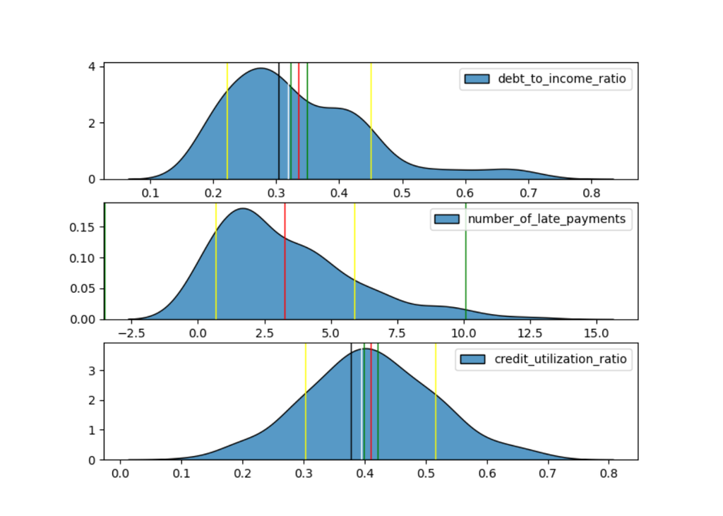

```r
im <- load.image("Distributions1.png")
par(mar = c(0, 0, 0, 0))
plot(im, axes=FALSE)
```

In the table above you can visually confirm the data given in the EDA:Such as the skewness of late payments and debt ratio. It should be noted that none of the number of late payments actually has a negative value, it is simply a result of the graphing technique that is smoothing the density distribution to be approximate.

This table shows each 1/4th percentile for :

- credit_utilization_ratio
- number_of_late_payments
- debt_to_income_ratio

```r
skimmedDFinitial <- df %>%
  skim() %>%
  yank("numeric")
skimmedDF <- skim(df) %>%
  dplyr::select(skim_variable, numeric.p25,numeric.p50, numeric.p75)
skimmedDF<-skimmedDF[4:6,]
kable(skimmedDF, digits = 2, align = "c") %>%
  kable_styling(
    full_width = FALSE,
    font_size = 11,
    latex_options = c("striped", "hold_position")
  ) %>%
  row_spec(0,font_size = 16, color = "white", background = "#2d9103") %>%
  row_spec(1:nrow(skimmedDF), color = "black", background = scales::seq_gradient_pal("green", "#2d9103")(seq(0, 1, length.out = nrow(skimmedDF)))) %>%
  column_spec(1, bold = TRUE, color = "black", background = "white") %>%
  add_header_above(c("Percentile's of each field" = ncol(skimmedDF)))
```

| Percentile's of each field skim_variable | Percentile's of each field numeric.p25 | Percentile's of each field numeric.p50 | Percentile's of each field numeric.p75 |
| --- | --- | --- | --- |
| number_of_late_payments | 1.00 | 2.00 | 5.00 |
| debt_to_income_ratio | 0.26 | 0.31 | 0.40 |
| credit_utilization_ratio | 0.34 | 0.41 | 0.48 |

These percentiles are then used to get the outliers of the data. Outliers are a good way of detecting and accounting for anomalies when conducting further tests on data.

```r
Q1m <- quantile(df$credit_utilization_ratio, .25)
Q3m <- quantile(df$credit_utilization_ratio, .75)
IQRm <- IQR(df$credit_utilization_ratio)

Q1w <- quantile(df$number_of_late_payments, .25)
Q3w <- quantile(df$number_of_late_payments, .75)
IQRw <- IQR(df$number_of_late_payments)

Q1s <- quantile(df$debt_to_income_ratio, .25)
Q3s <- quantile(df$debt_to_income_ratio, .75)
IQRs <- IQR(df$debt_to_income_ratio)


outliers <- subset(df,
                     df$credit_utilization_ratio<(Q1m - 1.5*IQRm)         | df$credit_utilization_ratio>(Q3m + 1.5*IQRm)        |
                     df$number_of_late_payments<(Q1w - 1.5*IQRw)   | df$number_of_late_payments>(Q3w + 1.5*IQRw)  |
                     df$debt_to_income_ratio<(Q1s - 1.5*IQRs) | df$debt_to_income_ratio>(Q3s + 1.5*IQRs)
                     )
o1<- subset(df,df$credit_utilization_ratio<(Q1m - 1.5*IQRm)         | df$credit_utilization_ratio>(Q3m + 1.5*IQRm)  )
o2<- subset(df,df$number_of_late_payments<(Q1w - 1.5*IQRw)   | df$number_of_late_payments>(Q3w + 1.5*IQRw)  )
o3<- subset(df,df$debt_to_income_ratio<(Q1s - 1.5*IQRs) | df$debt_to_income_ratio>(Q3s + 1.5*IQRs))
outliers<-outliers[,]
kable(outliers, digits = 0.02, align = "c") %>%
  kable_styling(
    full_width = FALSE,
    font_size = 11,
    latex_options = c("striped", "hold_position")
  )  %>%
  row_spec(0,font_size = 16, color = "white", background = "#2d9103")%>%
  column_spec(1, bold = TRUE, color = "black", background = "white")  %>%
  add_header_above(c("Table of outliers" = ncol(outliers)+1))
```

| Table of outliers | Table of outliers id | Table of outliers occupation | Table of outliers credit_rating | Table of outliers number_of_late_payments | Table of outliers debt_to_income_ratio | Table of outliers credit_utilization_ratio |
| --- | --- | --- | --- | --- | --- | --- |
| 5 | 5 | Clerk | Poor | 4 | 1 | 1 |
| 17 | 17 | Teacher | Poor | 7 | 0 | 1 |
| 18 | 18 | Engineer | Fair | 1 | 0 | 0 |
| 36 | 36 | Engineer | Fair | 2 | 1 | 0 |
| 40 | 40 | Clerk | Poor | 4 | 1 | 1 |
| 42 | 42 | Salesperson | Poor | 3 | 1 | 1 |
| 76 | 76 | Salesperson | Fair | 13 | 0 | 0 |
| 77 | 77 | Teacher | Fair | 5 | 1 | 0 |
| 91 | 91 | Engineer | Fair | 1 | 1 | 0 |
| 106 | 106 | Nurse | Poor | 3 | 1 | 1 |
| 158 | 158 | Engineer | Poor | 6 | 1 | 1 |
| 201 | 201 | Teacher | Poor | 10 | 1 | 0 |
| 224 | 224 | Manager | Fair | 12 | 0 | 0 |

```r
 my_df <- data.frame(
      d = "Outliers",
      credit_utilization_ratio =  nrow(o1),
      number_of_late_payments = nrow(o2),
      debt_to_income_ratio = nrow(o3)
    )
colnames(my_df)[1] <-""

    # Create a kable table
kable(my_df, align = "c")%>%
  kable_styling(
    full_width = FALSE,
    font_size = 11,
    latex_options = c("striped", "hold_position")
  )  %>%
    row_spec(0,font_size = 16, color = "white", background = "#2d9103")  %>%
    column_spec(1, bold = TRUE, color = "black", background = "white")%>%
    add_header_above(c("Number of outliers per independant variable" = ncol(my_df)))
```

| Number of outliers per independant variable | Number of outliers per independant variable credit_utilization_ratio | Number of outliers per independant variable number_of_late_payments | Number of outliers per independant variable debt_to_income_ratio |
| --- | --- | --- | --- |
| Outliers | 2 | 2 | 9 |

Since there are only 2 outliers in the credit utilization ratio and number of late payments columns, they probably will not impact any of the upcoming analysis. There is however a high amount of outliers in the debt to income ratio column. This can be due to the high skewness and kurtosis of debt_to_income_ratio. It is still important to include outliers in data analysis unless there are clear reasons to exclude them. But if any inconsistencies appear in the results, it may be worthwhile to check if the outliers are causing these issues. It should also be noted from the table of outliers that only “Poor” and “Fair” credit ratings are in the outliers.

## 3 Compring Data

### 3.1 Checking regression lines

This section compares certain fields with each other to see if they have any significant statistical correlation. the fields being compared are:

- (number_of_late_payments,credit_utilization_ratio)
- (credit_utilization_ratio,debt_to_income_ratio)
- (debt_to_income_ratio,number_of_late_payments)

The Pearson correlation coefficient:

- A value close to 1 indicates a strong positive linear relationship.
- A value close to -1 indicates a strong negative linear relationship.
- A value close to 0 suggests there is little to no linear relationship between the variables.

P-value:

- A p-value below a common limit such as 0.05 would indicate that the observed correlation is statistically significant.
- A p-value higher than 0.05 suggests that there is no statistical significant correlation between the variables.

#### 3.1.1 number_of_late_payments VS debt_to_income_ratio

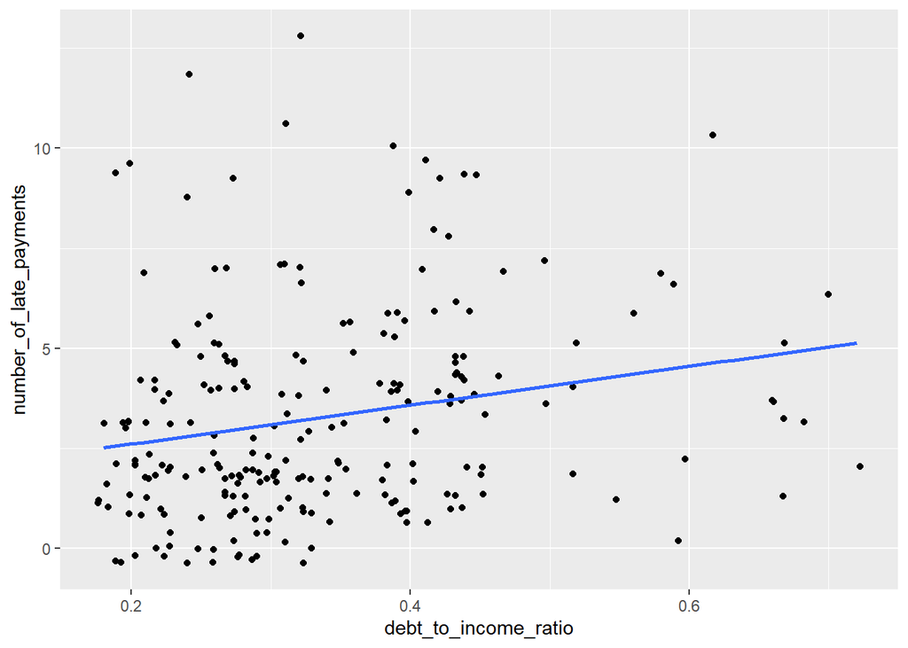

```r
ggplot(df,aes(x=debt_to_income_ratio,y=number_of_late_payments))+
  geom_jitter()+geom_smooth(method="lm",se=FALSE)+
  xlab("debt_to_income_ratio")+ylab("number_of_late_payments")
```

```python
f = open("c1.txt", "r").read()
print(f)
```

```
{
    "name1": "debt_to_income_ratio",
    "name2": "number_of_late_payments",
    "pearson_coefficient": 0.21345484679247573,
    "pearson_p_value": 0.0011252254123582809,
    "regression_line": "y=1.6358238247930679+4.856927427392359*x"
}
```

#### 3.1.2 credit_utilization_ratio VS debt_to_income_ratio

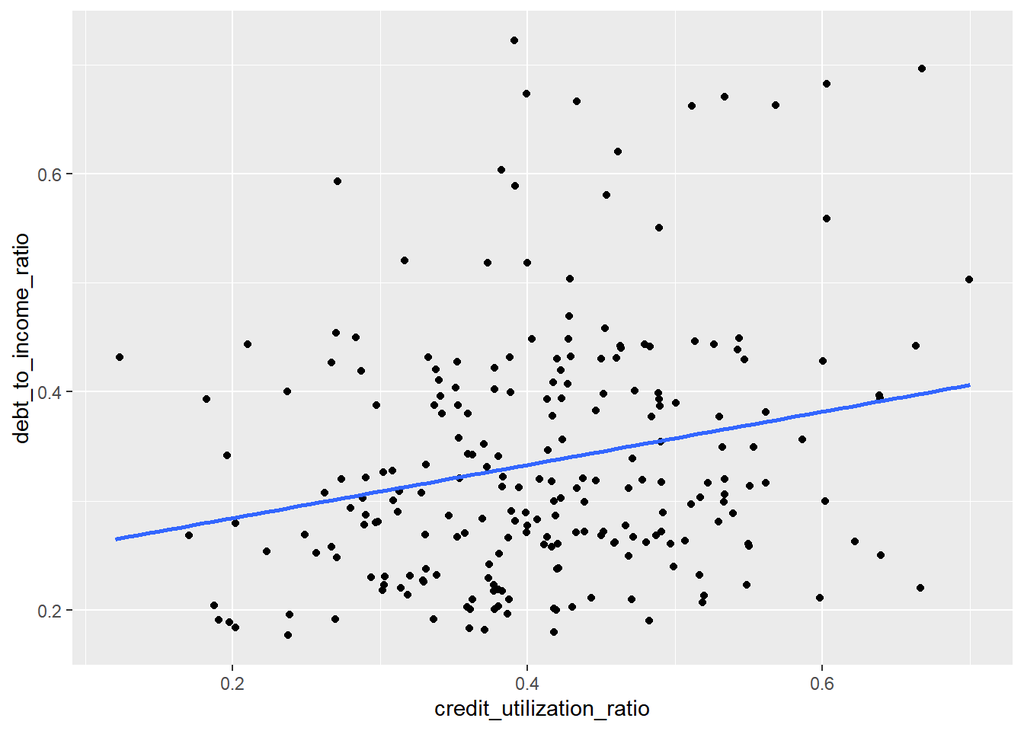

```r
ggplot(df,aes(x=credit_utilization_ratio,y=debt_to_income_ratio))+
  geom_jitter()+geom_smooth(method="lm",se=FALSE)+
  xlab("credit_utilization_ratio")+ylab("debt_to_income_ratio")
```

```python
f = open("c2.txt", "r").read()
print(f)
```

```
{
    "name1": "credit_utilization_ratio",
    "name2": "debt_to_income_ratio",
    "pearson_coefficient": 0.22665626214920925,
    "pearson_p_value": 0.0005324569590632021,
    "regression_line": "y=0.23559770056582663+0.2438438474669343*x"
}
```

#### 3.1.3 number_of_late_payments VS credit_utilization_ratio

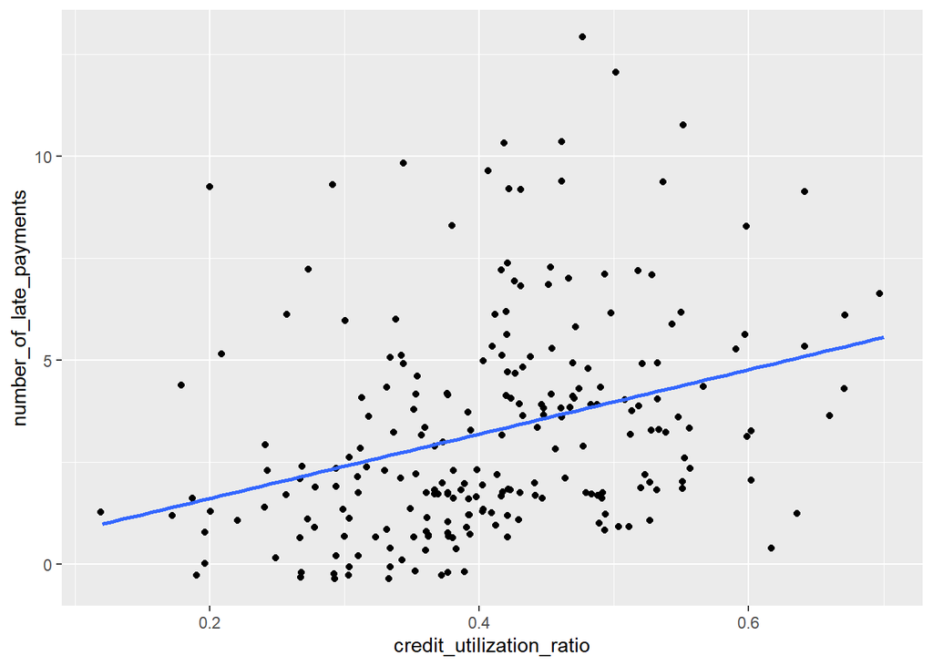

```r
ggplot(df,aes(x=credit_utilization_ratio,y=number_of_late_payments))+
  geom_jitter()+geom_smooth(method="lm",se=FALSE)+
  xlab("credit_utilization_ratio")+ylab("number_of_late_payments")
```

```python
f = open("c3.txt", "r").read()
print(f)
```

```
{
    "name1": "number_of_late_payments",
    "name2": "credit_utilization_ratio",
    "pearson_coefficient": 0.32234356257134733,
    "pearson_p_value": 5.854980429006792e-07,
    "regression_line": "y=0.36661236154571053+0.013167985145787717*x"
}
```

Below are the visual comparisons of each type of credit rating using box plots

#### 3.2.1 debt to income ratio

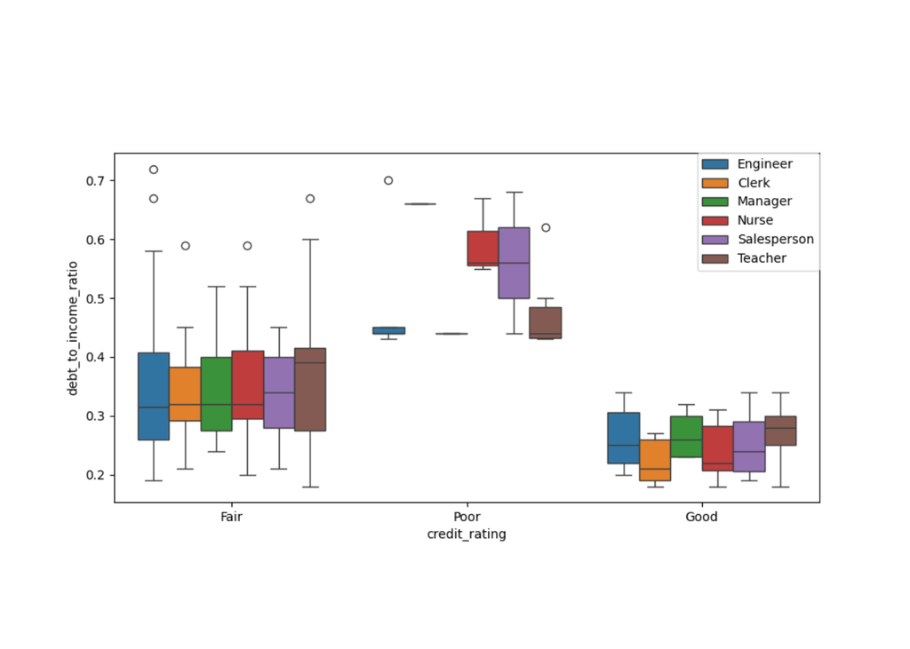

```r
im <- load.image("BoxC.png")
par(mar = c(0, 0, 0, 0))
plot(im, axes=FALSE)
```

#### 3.2.2 Number of late payments and credit utilization ratio

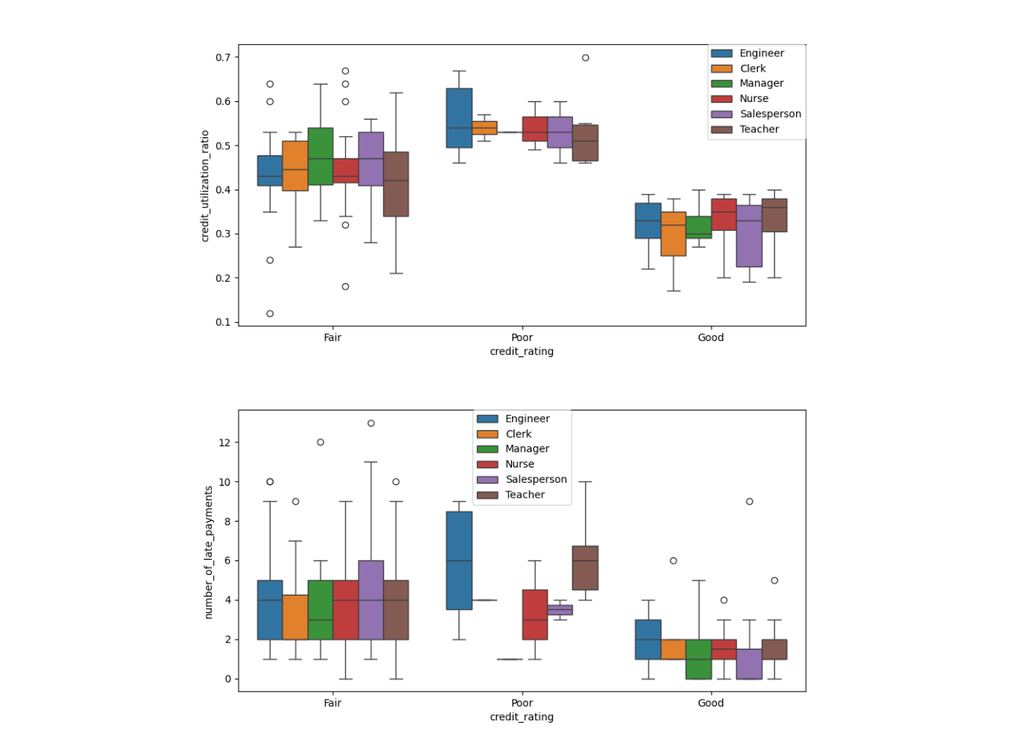

```r
par(mfrow = c(2, 1))

im <- load.image("BoxM.png")
par(mar = c(0, 0, 0, 0))
plot(im, axes=FALSE)

im <- load.image("BoxW.png")
par(mar = c(0, 0, 0, 0))
plot(im, axes=FALSE)
```

## 4 Statistical Inference

This section is for statistical inference.

### 4.1 Estimation

#### 4.1.1 Goodness-of-fit Test

Using a Shapiro-wilk test to do a goodness of fit test on the credit_utilization_ratio The test will check Normal, Gamma and Lognormal distributions.

```r
chosenDist<-EnvStats::distChoose(y=df$credit_utilization_ratio)
chosenDist
```

```
Results of Choosing Distribution
--------------------------------

Candidate Distributions:         Normal
                                 Gamma
                                 Lognormal

Choice Method:                   Shapiro-Wilk

Type I Error per Test:           0.05

Decision:                        Normal

Estimated Parameter(s):          mean = 0.4096087
                                 sd   = 0.1064444

Estimation Method:               mvue

Data:                            df$credit_utilization_ratio

Sample Size:                     230

Test Results:

  Normal
    Test Statistic:              W = 0.9954637
    P-value:                     0.7329635

  Gamma
    Test Statistic:              W = 0.9831784
    P-value:                     0.007872058

  Lognormal
    Test Statistic:              W = 0.9625792
    P-value:                     9.888096e-06
```

From this test we can see that it is most likely that the credit utilization ratio has a normal distribution as that has the highest test statistic and p value.

This graph shows the density distribution of credit utilization ratio and the expected density based off of the mean, standard deviation and variance of the sample data.

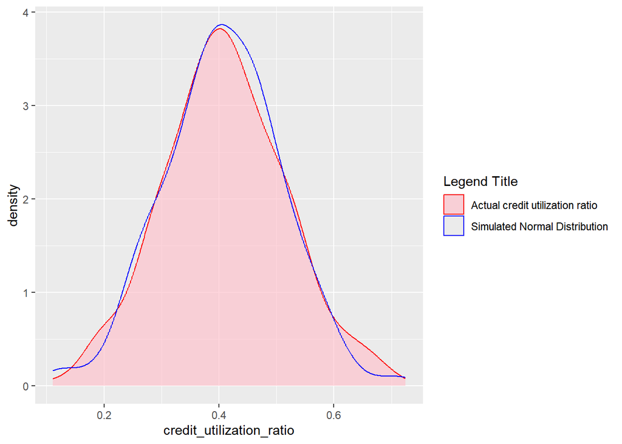

```r
ggplot(df, aes(x = credit_utilization_ratio)) +
  geom_density(aes(colour = "Actual credit utilization ratio"), fill = "pink", alpha = 0.65) +

  geom_density(aes(x = rnorm(n = length(credit_utilization_ratio),
                             mean = mean(credit_utilization_ratio),
                             sd = sd(credit_utilization_ratio)),
                   colour = "Simulated Normal Distribution"), fill = "blue", alpha = 0.0) +

  scale_colour_manual(values = c("Actual credit utilization ratio" = "red",
                                 "Simulated Normal Distribution" = "blue")) +

  guides(colour = guide_legend(title = "Legend Title"))
```

This provides a visual confirmation that credit utilization ratio has a normal distribution.

### 4.2 Interval Estimation

Density Plot for credit utilization ratio, with Shaded Critical Regions of alpha value 0.05. This graph of the credit utilization ratio shows the rejection regions using the critical values.

```r
alpha <- 0.05
critical_value_left <- qnorm(alpha / 2, mean = mean(df$credit_utilization_ratio), sd = sd(df$credit_utilization_ratio))
critical_value_right <- qnorm(1 - alpha / 2, mean = mean(df$credit_utilization_ratio), sd = sd(df$credit_utilization_ratio))
cat(
paste(" lower bound :", critical_value_left, sep=" "),"\n",
paste("upper bound :", critical_value_right, sep=" ")
)
```

```
 lower bound : 0.200981472092954
 upper bound : 0.618235919211394
```

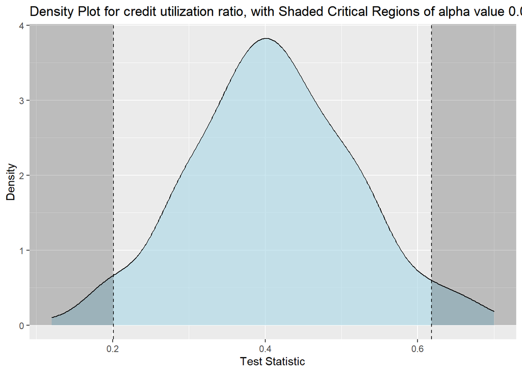

```r
ggplot(df, aes(x = credit_utilization_ratio)) +
  geom_density(fill = "lightblue", alpha = 0.65) +
  geom_vline(xintercept = c(critical_value_left, critical_value_right),
             linetype = "dashed", color = "black") +
  annotate("rect", xmin = -Inf, xmax = critical_value_left, ymin = 0, ymax = Inf,
           alpha = 0.2, fill = "black") +
  annotate("rect", xmin = critical_value_right, xmax = Inf, ymin = 0, ymax = Inf,
           alpha = 0.2, fill = "black") +
  labs(title = "Density Plot for credit utilization ratio, with Shaded Critical Regions of alpha value 0.05 ", x = "Test Statistic",y="Density")
```

### 4.3 Hypothesis testing

```r
a <- EnvStats::varTest(x=df$credit_utilization_ratio,conf.level = 0.05)
a$method
```

```
[1] "Chi-Squared Test on Variance"
```

```r
a
```

```
Results of Hypothesis Test
--------------------------

Null Hypothesis:                 variance = 1

Alternative Hypothesis:          True variance is not equal to 1

Test Name:                       Chi-Squared Test on Variance

Estimated Parameter(s):          variance = 0.01133041

Data:                            df$credit_utilization_ratio

Test Statistic:                  Chi-Squared = 2.594665

Test Statistic Parameter:        df = 229

P-value:                         1.784685e-175

5% Confidence Interval:          LCL = 0.01129707
                                 UCL = 0.01143041
```

With this we can see that the p-value is much less that the test statistic. therefore we reject the null hypothesis, meaning that we have strong statistical evidence to say that the actual variance of credit_utilization_ratio is not equal to 1.

## 5 Insights and Conclusion

Interesting observation

```r
anova_late_payments <- aov(number_of_late_payments ~ credit_rating, data = df)
summary(anova_late_payments)
```

```
               Df Sum Sq Mean Sq F value   Pr(>F)
credit_rating   2  325.4  162.71   30.04 2.66e-12 ***
Residuals     227 1229.4    5.42
---
Signif. codes:  0 '***' 0.001 '**' 0.01 '*' 0.05 '.' 0.1 ' ' 1
```

```r
anova_dti <- aov(debt_to_income_ratio ~ credit_rating, data = df)
summary(anova_dti)
```

```
               Df Sum Sq Mean Sq F value Pr(>F)
credit_rating   2  1.214  0.6069   76.99 <2e-16 ***
Residuals     227  1.789  0.0079
---
Signif. codes:  0 '***' 0.001 '**' 0.01 '*' 0.05 '.' 0.1 ' ' 1
```

```r
anova_utilization <- aov(credit_utilization_ratio ~ credit_rating, data = df)
summary(anova_utilization)
```

```
               Df Sum Sq Mean Sq F value Pr(>F)
credit_rating   2  1.109  0.5545   84.72 <2e-16 ***
Residuals     227  1.486  0.0065
---
Signif. codes:  0 '***' 0.001 '**' 0.01 '*' 0.05 '.' 0.1 ' ' 1
```

### 5.1 Recommendations

Based on the box plots and the anova test: if someone has a bad credit rating and would like to improve it, they should: lower their credit utilisation ratio(spend less of your total available credit), and they should make less late payments. They must also most importantly reduce their debt to income ratio.